# RNewsflow: Tools for analyzing content homogeneity and news diffusion using computational text analysis

by Kasper Welbers and Wouter van Atteveldt

## Abstract

> Given the sheer amount of news sources in the digital age (e.g., newspapers, blogs, social media) it has become difficult to determine where news is first introduced and how it diffuses across sources. RNewsflow provides tools for analyzing content homogeneity and diffusion patterns using computational text analysis. The content of news messages is compared using techniques from the field of information retrieval, similar to plagiarism detection. By using a sliding window approach to only compare messages within a given time distance, many sources can be compared over long periods of time. Furthermore, the package introduces an approach for analyzing the news similarity data as a network, and includes various functions to analyze and visualize this network.

# Introduction

The news diffusion process in the digital age involves many interdependent sources, ranging from news agencies and traditional newspapers to blogs and people on social media (Meraz 2011; Paterson 2005; Pew Research Center 2010). We offer the `RNewsflow` R package as a toolkit to analyze the homogeneity and diffusion of news content using computational text analysis. This analysis consists of two steps. First, techniques from the field of information retrieval are used to measure the similarity of news messages (e.g., addressing the same event, containing identical phrases). Second, the temporal order in which messages are published is used to analyze consistent patterns in who follows whom.

The main contribution of this package lies in the specialized application of document similarity measures for the purpose of comparing news messages. News is a special type of information in the sense that it has a time dimension—it quickly loses its relevance. Therefore, we are often only interested in the similarity of news documents that occured within a short time distance. By restricting document comparisons to a given time distance, it becomes possible to compare many documents over a long period of time, but available document comparison software generally does not have this feature. We therefore offer the `newsflow.compare` function which compares documents using a sliding window over time. In addition, this package offers tools to aggregate, analyze and visualize the document similarity data. By covering all steps of the text and data analysis in a single R package, it becomes easier to develop and share methods, and analyses become more transparent and replicable.

The primary intended audience of this package is scholars and professionals in fields where the impact of news on society is a prime factor, such as journalism, political communication and public relations (Baum and Groeling 2008; Boczkowski and De Santos 2007; Ragas 2014). To what extent the content of certain sources is homogeneous or diverse has implications for central theories of media effects, such as agenda-setting and the spiral of silence (Bennett and Iyengar 2008; Blumler and Kavanagh 1999). Identifying patterns in how news travels from the initial source to the eventual audience is important for understanding who the most influential “gatekeepers” are (Shoemaker and Vos 2009). Furthermore, the document similarity data enables one to study news values (Galtung and Ruge 1965) by analyzing what elements of news predict their diffusion rate and patterns.

The package is designed to appeal to scholars and professionals without prior experience in computational text analysis. This vignette covers the entire chain from processing raw data—written text with source and date information—to analyzing and visualizing the output. It points to relevant software within and outside of R for pre-processing written texts, and demonstrates how to use the core functions of this package. For more advanced users there are additional functions and parameters to support versatility. `RNewsflow` is completely open-source to promote active involvement in developing and evaluating the methodology. The source code is available on Github—https://github.com/kasperwelbers/RNewsflow. All data used in this vignette is included in the package for easy replication.

The structure of this vignette is as follows. The first part discusses the data preparation. There are several choices to be made here that determine on what grounds the content of documents is compared. The second part shows how the core function of this packages, `newsflow.compare`, is used to calculate document similarities for many documents over time. The third part demonstrates functions for exploring, aggregating and visualizing the document similarity data. Finally, conclusions regarding the current version of the package and future directions are discussed.

# Preparing the data

To analyze content homogeneity and news diffusion using computational text analysis, we need to know *who* said *what* at *what time*. Thus, our data consists of messages in text form, including meta information for the source and publication date of each message. The texts furthermore need to be pre-processed and represented as a *document-term matrix* (DTM). This section first discusses techniques and refers to existing software to pre-process texts and create the DTM, and reflects on how certain choices influence the analysis. Second, it shows how the source and date information should be organized. Third, it discusses several ways to filter and weight the DTM based on word statistics.

## Pre-processing texts and creating the DTM

A DTM is a matrix in which rows represent documents, columns represent terms, and cells indicate how often each term occurred in each document. This is referred to as a *bag of words* representation of texts, since we ignore the order of words. This simplified representation makes analysis much easier and less computationally demanding, and as research has shown: ``a simple list of words, which we call unigrams, is often sufficient to convey the general meaning of a text’’ (Grimmer and Stewart 2013: 6).

As input for this package, the DTM can either be in the `dfm` class of the `quanteda` package (Benoit 2018) or in the `DocumentTermMarix` class of the `tm` package (Feinerer, Hornik, and Meyer 2008). We recommend using `quanteda`, because the `dfm` class can contain the document meta data (called `docvars` in `quanteda`), and is generally more efficient and versatile. For detailed instructions you can visit the [quanteda website](https://quanteda.io/). Here we will demonstrate one of the easiest ways to create a DTM with the meta data included, based on a data.frame. We first create a corpus with the `corpus` function, and then process this corpus into a DTM with the `dfm` function.

```r
library(quanteda)
d = data.frame(id = c(1,2,3),
               text = c('Socrates is human', 'Humans are mortal', 'Therefore, Socrates is mortal'),
               author = c('Aristotle','Aristotle','Aristotle'),
               stringsAsFactors = F)

corp = corpus(d, docid_field = 'id', text_field='text')
dtm = dfm(corp)

dtm
```

```
## Document-feature matrix of: 3 documents, 8 features (54.2% sparse).
## 3 x 8 sparse Matrix of class "dfm"
##     features
## docs socrates is human humans are mortal therefore ,
##    1        1  1     1      0   0      0         0 0
##    2        0  0     0      1   1      1         0 0
##    3        1  1     0      0   0      1         1 1
```

```r
docvars(dtm)
```

```
##      author
## 1 Aristotle
## 2 Aristotle
## 3 Aristotle
```

Based on the representation of texts in the DTM, the similarity of documents can be calculated as the similarity of row vectors. However, as seen in the example, this approach has certain pitfalls if we simply look at all words in their literal form. For instance, the words “human” and “humans” are given separate columns, despite having largely the same meaning. As a result, this similarity of the first two texts is not recognized. Also, the words “are”, and “is” do not have any substantial meaning, so they are not informative and can be misleading for the calculation of document similarity. There are various `preprocessing` techniques to filter and transform words that can be used to mend these issues. In addition, we can use these techniques to steer on what grounds documents are compared.

- First of all, it is advisable to make all terms lowercase, and reduce terms to their root using stemming or lemmatization[^1]. Thus, “Hope”, “hoped”, “hoping”, etc. all become “hope”. This is because we are (often) interested in the meaning of these terms, and not the specific form in which they are used.
- Second, one should filter out irrelevant words. Very common words, stopwords and boilerplate words contain little or no relevant information about news items. Very rare terms, while ignored in many computational text analysis approaches, can be particularly informative for comparing news items, and should probably be kept.
- Third, it is also possible to specifically select or filter out only certain types of words by using part-of-speech tagging[^2]. For instance, to compare whether documents address the same event one can focus on nouns and proper names.
- Finally, an alternative approach is to combine words into N-grams (i.e. sets of N consecutive words). This way the comparison of documents focuses more on similarity in specific segments of text, which is useful if the goal is to trace whether sources literally copy each other (in which case most other pre-processing steps can be skipped).

All mentioned preprocessing techniques except for lemmatization and part-of-speech tagging can be used in quanteda (as arguments in the `dfm` function). To use lemmatization or part-of-speech tagging there are several free to use grammar parsers, such as *CoreNLP* for English (Manning et al. 2014) and *Frog* for Dutch (Van den Bosch et al. 2007). For more information about preprocessing, please consult (Welbers, Atteveldt, and Benoit 2017).

For this vignette, data is used that has been preprocessed with the Dutch grammar parser Frog. The data is based on a recent study on the influence of a Dutch news agency on the print and online editions of Dutch newspapers in political news coverage (Welbers et al. 2018). The terms have been lemmatized, and only the nouns and proper names of the headline and first five sentences (that generally contain the essential who, what and where of news) are used. By focusing on these elements, the analysis in this study focused on whether documents address the same events. This data is also made available in the package as demo data, in which the actual nouns and proper names have been substituted with indexed word types (e.g., the third organization in the vocabulary is referred to as organization.3, the 20th noun as noun.20).

```r
library(RNewsflow)

dtm = rnewsflow_dfm ## copy the demo data
dtm
```

```
## Document-feature matrix of: 1,754 documents, 6,968 features (99.6% sparse).
```

To compare news across media and over time, it is necessary to have meta data about the date of a document, and convenient to have meta data about the source of a document. In the demo data, this is included as the `docvars` of the `dfm`. Note that if the `DocumentTermClass` class of the `tm` package is used, the meta data has to be managed manually, as a data.frame in which the rows (i.e. documents) match the rows (i.e. documents) in the DTM.

```r
head(docvars(dtm), 3)
```

```
##                         date     source sourcetype
## 35573532 2013-06-01 06:00:00 Print NP 2   Print NP
## 35573536 2013-06-01 06:00:00 Print NP 2   Print NP
## 35573539 2013-06-01 06:00:00 Print NP 2   Print NP
```

## Using word statistics to filter and weight the DTM

As a final step in the data preparation, we can filter and weight words based on word statistics, such as how often a word occured. Since we are analyzing news diffusion, a particularly interesting characteristic of words is the distribution of their use over time. To focus the comparison of documents on words that indicate new events, we can filter out words that are evenly used over time. To calculate this, we provide the `term.day.dist` function.

```r
tdd = term.day.dist(dtm)
tail(tdd, 3)
```

```
##              term freq doc.freq days.n days.pct days.entropy
## 6966 location.320    2        2      2   0.0667         2.00
## 6967    noun.3667    4        4      2   0.0667         1.75
## 6968    noun.1021    7        7      3   0.1000         2.94
##      days.entropy.norm
## 6966            0.0667
## 6967            0.0585
## 6968            0.0981
```

Of particular interest is the `days.entropy` score, which is the entropy of the distribution of words over days. This tells us whether the occurrence of a word over time is evenly distributed (high entropy) or concentrated (low entropy).[^3] The maximum value for entropy is the total number of days (in case of a uniform distribution). The `days.entropy.norm` score normalizes the entropy by dividing by the number of days. By selecting the terms with low entropy scores, the DTM can be filtered by using the selected terms as column values.

```r
select_terms = tdd$term[tdd$days.entropy.norm <= 0.3]
dtm = dtm[,select_terms]
```

In addition to deleting terms, we should also weight terms. Turney explains that ‘’The idea of weighting is to give more weight to surprising events and less weight to expected events’‘, which is important because’‘surprising events, if shared by two vectors, are more discriminative of the similarity between the vectors than less surprising events’’ (Turney 2002: 156). Thus, we want to give more weight to rare words than common words. A classic weighting scheme and recommended standard in information retrieval is the term-frequency inverse document frequency (tf.idf) (Sparck Jones 1972,Monroe, Colaresi, and Quinn (2008)). This and other weighting schemes can easily be applied using the `quanteda` package, for instance using the `dfm_tfidf` function.

```r
dtm = quanteda::dfm_tfidf(dtm)
```

# Calculating document similarities

Given a DTM and corresponding document meta data, the document similarities over time can be calculated with the `newsflow.compare` function. The calculation of document similarities is performed using a vector space model (Salton, Wong, and Yang 1975; Salton and Harman 2003) approach, but with a sliding window over time to only compare document that occur within a given time distance. The function has two main data inputs: the DTM and a data.frame with meta information. The meta data.frame should have a column containing document id’s that match the rownames of the DTM (i.e. documents) and should have a column indicating the publication time. By default these columns should be labeled “document_id” and “date”, but the column labels can also be set using the `id.var` and `date.var` parameters. Any other columns (in our case “source” and “sourcetype”) will automatically be included as document meta information in the output.

Furthermore, three parameters are of particular importance. The `hour.window` parameter determines the time window in hours within which each document is compared to other documents. The argument is a vector of length 2, in which the first and second value determine the left and right side of the window, respectively. For example, c(0, 36) will compare each document to all documents within the next 36 hours. The `measure` parameter, which determines what measure for similarity is used, defaults to *cosine similarity*[^4]. This is a commonly used measure, which indicates similarity as a score between 0 (no similarity) and 1 (identical)[^5]. The `min.similarity` parameter is used to ignore all document pairs below a certain similarity score. In the current example we use a minimum similarity of 0.4, because a validity test in the paper from which the current data is taken found this to be a good threshold for finding documents that address the same events. Whether or not a threshold should be used and what the value should be depends on the goal of the analysis and the data. We recommend manual validation to verify that the similarity threshold matches human interpretation of whether or not two documents are similar, given a pre-defined interpretation of similarity (e.g., same event, same theme).

```r
g = newsflow.compare(dtm, hour.window = c(0,36), min.similarity = 0.4)
```

The output `g` is a network, or graph, in the format of the `igraph` package [Csardi and Nepusz (2006)}. The vertices (or nodes) of this network represent documents, and the date and source of each document are stored as vertex attributes. The edges (or ties) represent the similarity of documents, and the similarity score and time difference are stored as edge attributes. To avoid confusion, keep in mind that from hereon when we talk about vertices or a vertex we are talking about documents, and that edges represent document pairs. An advantage of using a network format is that it combines this data in an efficient way, without copying the document meta information for each edge. This network forms the basis for all the analysis functions offered in this package[^6].

A full understanding of the `igraph` package is not required to use the current package, but one does need some basic understanding of the functions for viewing and extracting the document/vertex and edge attributes. First, vertex and edge attributes cannot directly be extracted using the `$` symbol, but require the functions `V()` and `E()` to be used, for vertex and edge attributes, respectively. These can be used as follows.

```r
vertex.sourcetype = V(g)$sourcetype
edge.hourdiff = E(g)$hourdiff

head(vertex.sourcetype)
```

```
## [1] "Online NP"  "Newsagency" "Newsagency" "Newsagency" "Print NP"
## [6] "Newsagency"
```

```r
head(edge.hourdiff)
```

```
## [1]  0.05  1.10  1.32  1.25 10.50  1.12
```

Alternatively, all vertex and edge attributes can be viewed or extracted with the `get.data.frame` function.

```r
v = get.data.frame(g, 'vertices')
e = get.data.frame(g, 'edges')

head(v,3)
```

```
##              name                date      source sourcetype
## 37538427 37538427 2013-06-20 11:27:00 Online NP 1  Online NP
## 97361198 97361198 2013-06-02 14:13:00  Newsagency Newsagency
## 97360803 97360803 2013-06-03 16:54:00  Newsagency Newsagency
```

```r
head(e,3)
```

```
##       from       to weight hourdiff
## 1 37538427 37599339      1     0.05
## 2 97361198 35677816      1     1.10
## 3 97360803 35734376      1     1.32
```

The `weight` attribute of the edges represents the similarity score. The `hourdiff` attribute represents the time difference in hours between two documents, where the value indicates how long the `to` article was published after the `from` article. A histogram can provide a good first indication of this data.

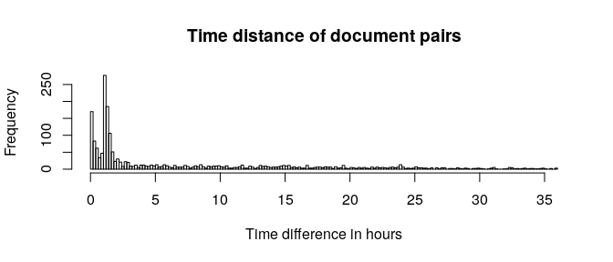

```r
hist(E(g)$hourdiff, main='Time distance of document pairs',
     xlab = 'Time difference in hours', breaks = 150)
```

In the histogram we see that most document pairs with a similarity score above the threshold are about an hour apart (1 on the x-axis). This is mainly because the online newspapers often follow the news agency within a very short amount of time{^delaynote]. As time distance increases, the number of document pairs decreases, which makes sense because news gets old fast, so news diffusion should occur within a limited time after publication.